# Ensemble: Combinando resultados de diferentes modelos

## Orientacoes para execucao

Todos os pacotes utilizados neste script devem ser/estar instalados no seu ambiente de desenvolvimento. Para instalar um pacote use o comando install.packages(“nome_do_pacote”)

## Configuração inicial

Carrega as bibliotecas necessárias

```r
library(mlbench)
library(caret)
library(caretEnsemble)
library(kernlab)
```

Carrega o dataset de exemplo

```r
# cria variavel para armazenar os dados
data(Ionosphere)
dataset_total <- Ionosphere

#removendo a segundo atributo, pois é uma variável constante
dataset_total <- dataset_total[,-2]

#converte a variavel 1 de factor para numeric
dataset_total$V1 <- as.numeric(as.character(dataset_total$V1))

#verifica os primeiros registros
head(dataset_total)
```

```
##   V1      V3       V4       V5       V6       V7       V8      V9      V10
## 1  1 0.99539 -0.05889  0.85243  0.02306  0.83398 -0.37708 1.00000  0.03760
## 2  1 1.00000 -0.18829  0.93035 -0.36156 -0.10868 -0.93597 1.00000 -0.04549
## 3  1 1.00000 -0.03365  1.00000  0.00485  1.00000 -0.12062 0.88965  0.01198
## 4  1 1.00000 -0.45161  1.00000  1.00000  0.71216 -1.00000 0.00000  0.00000
## 5  1 1.00000 -0.02401  0.94140  0.06531  0.92106 -0.23255 0.77152 -0.16399
## 6  1 0.02337 -0.00592 -0.09924 -0.11949 -0.00763 -0.11824 0.14706  0.06637
##       V11      V12     V13      V14      V15      V16      V17      V18
## 1 0.85243 -0.17755 0.59755 -0.44945  0.60536 -0.38223  0.84356 -0.38542
## 2 0.50874 -0.67743 0.34432 -0.69707 -0.51685 -0.97515  0.05499 -0.62237
## 3 0.73082  0.05346 0.85443  0.00827  0.54591  0.00299  0.83775 -0.13644
## 4 0.00000  0.00000 0.00000  0.00000 -1.00000  0.14516  0.54094 -0.39330
## 5 0.52798 -0.20275 0.56409 -0.00712  0.34395 -0.27457  0.52940 -0.21780
## 6 0.03786 -0.06302 0.00000  0.00000 -0.04572 -0.15540 -0.00343 -0.10196
##        V19      V20      V21      V22      V23      V24      V25      V26
```

[output cut: 20 more lines]

Configura alguns parâmetros gerais

```r
#garante reprodutividade do código
set.seed(123)

# Define nossa métrica para avaliação do modelo
metric <- "Accuracy"
```

Separa o dataset entre treino e teste

```r
s <-createDataPartition(y=dataset_total$Class,p=0.7,list=FALSE)
dataset <-dataset_total[s,]
dataset_test <-dataset_total[-s,]
```

## Ensemble usando stacking

Criaremos 5 modelos primários:

- Linear Discriminate Analysis (LDA)
- Classification and Regression Trees (CART)
- Logistic Regression (via Generalized Linear Model or GLM)
- k-Nearest Neighbors (KNN)
- Support Vector Machine with a Radial Basis Kernel Function (SVM)

```r
# Parâmetros de controle do treino
trainControl <- trainControl(method="repeatedcv", number=10, repeats=3, savePredictions=TRUE, classProbs=TRUE)

# Lista de algoritmos que serão utilziados
algorithmList <- c('lda', 'rpart', 'glm', 'knn', 'svmRadial')

# Cria os modelos da lista
models <- caretList(Class~., data=dataset, trControl=trainControl, methodList=algorithmList)

# Resultado
results <- resamples(models)
summary(results)
```

```
##
## Call:
## summary.resamples(object = results)
##
## Models: lda, rpart, glm, knn, svmRadial
## Number of resamples: 30
##
## Accuracy
##           Min. 1st Qu. Median   Mean 3rd Qu. Max. NA's
## lda       0.72  0.8400 0.8800 0.8772  0.9167 1.00    0
## rpart     0.76  0.8488 0.8800 0.8852  0.9200 0.96    0
## glm       0.60  0.8000 0.8750 0.8571  0.9200 1.00    0
## knn       0.72  0.8400 0.8800 0.8692  0.9075 0.96    0
## svmRadial 0.84  0.9200 0.9592 0.9516  1.0000 1.00    0
##
## Kappa
##              Min. 1st Qu. Median   Mean 3rd Qu.  Max. NA's
## lda       0.30830  0.6154 0.7191 0.7094  0.8140 1.000    0
## rpart     0.50330  0.6671 0.7394 0.7436  0.8175 0.913    0
## glm       0.08759  0.5763 0.7143 0.6800  0.8242 1.000    0
## knn       0.30830  0.6185 0.7191 0.6927  0.7864 0.911    0
## svmRadial 0.63500  0.8284 0.9101 0.8938  1.0000 1.000    0
```

Note que o melhor resultado individual alcançado foi o SVM.

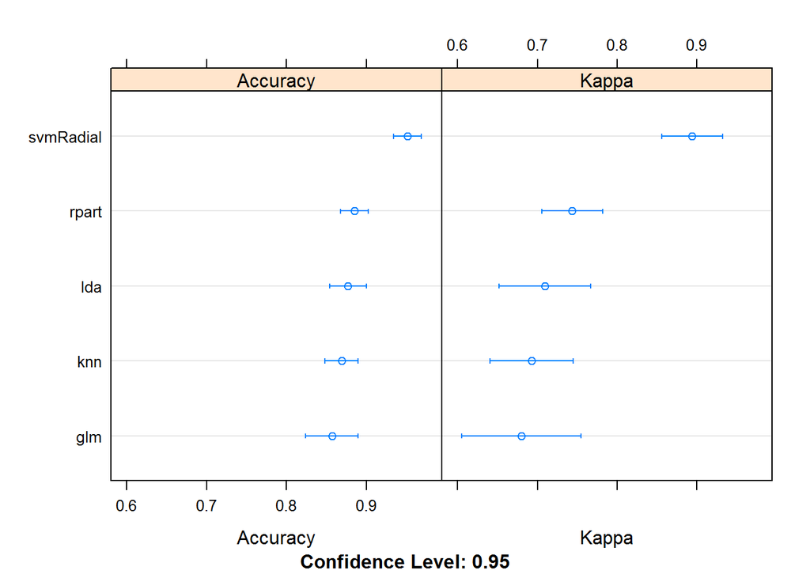

```r
dotplot(results)
```

Agora vamos verificar a correlação entre os modelos primários. Modelos altamente correlacionados tendem a não melhorar o resultado final.

```r
modelCor(results)
```

```
##                 lda     rpart       glm       knn svmRadial
## lda       1.0000000 0.3678967 0.4528889 0.5334170 0.4955626
## rpart     0.3678967 1.0000000 0.1072982 0.3674918 0.1723151
## glm       0.4528889 0.1072982 1.0000000 0.3232918 0.3482163
## knn       0.5334170 0.3674918 0.3232918 1.0000000 0.6319837
## svmRadial 0.4955626 0.1723151 0.3482163 0.6319837 1.0000000
```

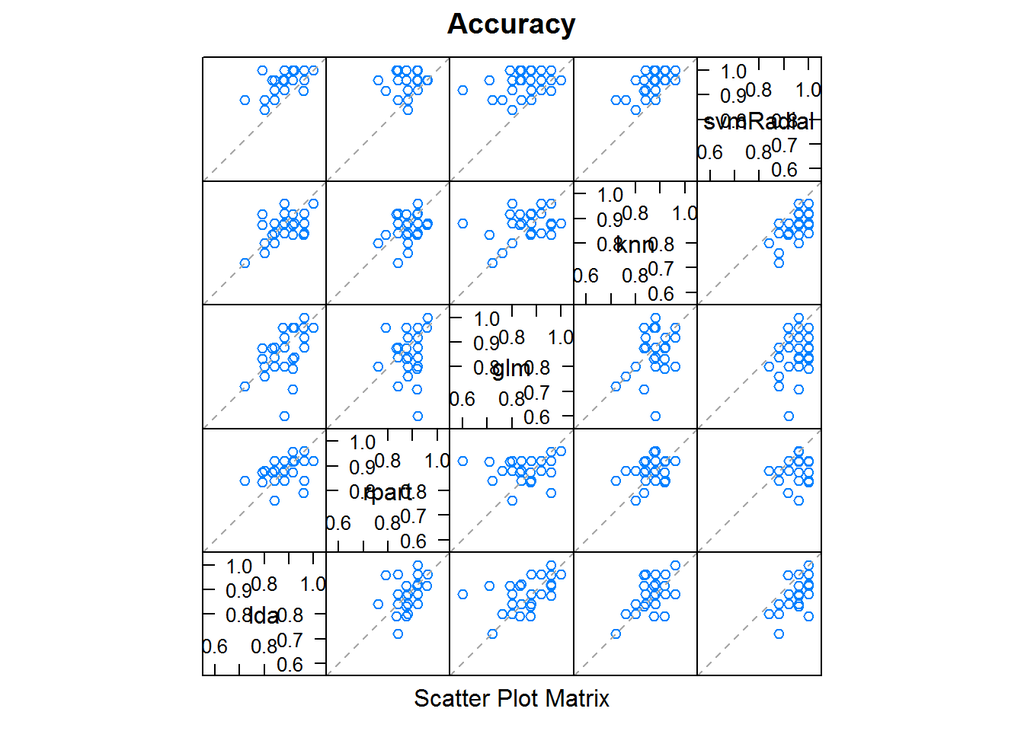

```r
splom(results)
```

Aparentemente não temos modelos correlacionados (geralmente com índice > 70%)

Ok, vamos fazer o primeiro stacking usando um modelo linear simples

```r
stackControl <- trainControl(method="repeatedcv", number=10, repeats=3, savePredictions=TRUE, classProbs=TRUE)
stack.glm <- caretStack(models, method="glm", metric="Accuracy", trControl=stackControl)
print(stack.glm)
```

```
## A glm ensemble of 2 base models: lda, rpart, glm, knn, svmRadial
##
## Ensemble results:
## Generalized Linear Model
##
## 741 samples
##   5 predictor
##   2 classes: 'bad', 'good'
##
## No pre-processing
## Resampling: Cross-Validated (10 fold, repeated 3 times)
## Summary of sample sizes: 666, 666, 667, 667, 667, 668, ...
## Resampling results:
##
##   Accuracy   Kappa
##   0.9564363  0.9054094
```

Note que a métrica accuracy melhorou com o ensemble.

Agora vamos fazer outro stacking, desta vez usando o algoritmo random forest.

```r
stack.rf <- caretStack(models, method="rf", metric="Accuracy", trControl=stackControl)
print(stack.rf)
```

```
## A rf ensemble of 2 base models: lda, rpart, glm, knn, svmRadial
##
## Ensemble results:
## Random Forest
##
## 741 samples
##   5 predictor
##   2 classes: 'bad', 'good'
##
## No pre-processing
## Resampling: Cross-Validated (10 fold, repeated 3 times)
## Summary of sample sizes: 667, 667, 666, 667, 666, 667, ...
## Resampling results across tuning parameters:
##
##   mtry  Accuracy   Kappa
##   2     0.9622024  0.9176879
##   3     0.9599558  0.9127389
##   5     0.9559316  0.9042234
##
## Accuracy was used to select the optimal model using  the largest value.
## The final value used for the model was mtry = 2.
```

Note que a métrica accuracy melhorou ainda mais.

## Verificando o peso dos modelos primários

Você pode usar o código abaixo para verificar o peso dos modelos primários do ensemble

```r
pesoModelos <- caretEnsemble(models)
summary(pesoModelos)
```

```
## The following models were ensembled: lda, rpart, glm, knn, svmRadial
## They were weighted:
## -4.4747 1.2949 1.6063 0.8711 -2.8858 8.1629
## The resulting Accuracy is: 0.9552
## The fit for each individual model on the Accuracy is:
##     method  Accuracy AccuracySD
##        lda 0.8772222 0.06222616
##      rpart 0.8852222 0.04656749
##        glm 0.8570556 0.08841374
##        knn 0.8691667 0.05531129
##  svmRadial 0.9516111 0.04630501
```

## Fazendo as previsões nos dados de teste

Executa o modelo nos dados de teste

```r
predictions <- predict(stack.rf, dataset_test)
```

Cria matriz de confusão para analisar o desempenho

```r
table(predictions, dataset_test$Class)
```

```
##
## predictions bad good
##        bad   31    2
##        good   6   65
```

Referências: Jason Brownlee, Machine Learning Mastery Veja também http://mlwave.com/kaggle-ensembling-guide/